# Golden State Warriors vs Houston Rockets 2025 Playoffs Round 1 Analysis (Games 1-3)

Roshan Cranford Luitel

2025-04-27

#### Load Libraries

```r
library(tidyverse)
library(hoopR)
library(knitr)
library(purrr)
```

#### Retrieve Playoff Series Game Data

```r
# 1. Pull 2024-25 playoff series metadata
series_meta <- hoopR::nba_commonplayoffseries(
  league_id = "00",
  season    = "2024-25")$PlayoffSeries

# 2. Look up the numeric team IDs for GSW and HOU
team_ids <- nba_commonallplayers(
  is_only_current_season = 1,
  league_id = "00",
  season    = "2024-25")$CommonAllPlayers %>%
  filter(TEAM_ABBREVIATION %in% c("GSW","HOU")) %>%
  select(TEAM_ABBREVIATION, TEAM_ID) %>%
  distinct()

gsw_id <- team_ids %>% filter(TEAM_ABBREVIATION=="GSW") %>% pull(TEAM_ID)
hou_id <- team_ids %>% filter(TEAM_ABBREVIATION=="HOU") %>% pull(TEAM_ID)

# 3. Filter the series for Warriors vs. Rockets
games_ids <- series_meta %>%
  filter((HOME_TEAM_ID == gsw_id & VISITOR_TEAM_ID == hou_id) |
           (HOME_TEAM_ID == hou_id & VISITOR_TEAM_ID == gsw_id)) %>%
  pull(GAME_ID)

# 4. Fetch boxscore stats
player_stats <- map_dfr(games_ids, ~hoopR::nba_boxscoretraditionalv2(game_id = .x)$PlayerStats)
team_stats   <- map_dfr(games_ids, ~hoopR::nba_boxscoretraditionalv2(game_id = .x)$TeamStats)
```

## Team Statistics

This section will look to evaluate how well the Warriors and the Rockets are playing as a team in the games that they won vs the games that they lost.

```r
# Select relevant data
stats <- team_stats %>%
  select(-TEAM_ID, -TEAM_NAME, -TEAM_CITY, -MIN)

# Make specific columns numeric
stats <- stats %>%
  mutate(across(FGM:PLUS_MINUS,
                ~ as.numeric(as.character(.))))


# Create win/loss column
stats <- stats %>%
  mutate(outcome = ifelse(PLUS_MINUS > 0, "W", "L"))

stats %>%
  kable(digits = 2)
```

| GAME_ID | TEAM_ABBREVIATION | FGM | FGA | FG_PCT | FG3M | FG3A | FG3_PCT | FTM | FTA | FT_PCT | OREB | DREB | REB | AST | STL | BLK | TO | PF | PTS | PLUS_MINUS | outcome |
| --- | --- | --- | --- | --- | --- | --- | --- | --- | --- | --- | --- | --- | --- | --- | --- | --- | --- | --- | --- | --- | --- |
| 0042400151 | HOU | 34 | 87 | 0.39 | 6 | 29 | 0.21 | 11 | 20 | 0.55 | 22 | 30 | 52 | 19 | 9 | 3 | 16 | 15 | 85 | -10 | L |
| 0042400151 | GSW | 36 | 76 | 0.47 | 12 | 32 | 0.38 | 11 | 14 | 0.79 | 6 | 30 | 36 | 20 | 14 | 1 | 11 | 18 | 95 | 10 | W |
| 0042400152 | HOU | 39 | 86 | 0.45 | 15 | 40 | 0.38 | 16 | 20 | 0.80 | 11 | 36 | 47 | 21 | 9 | 4 | 10 | 17 | 109 | 15 | W |
| 0042400152 | GSW | 33 | 80 | 0.41 | 17 | 43 | 0.40 | 11 | 18 | 0.61 | 7 | 26 | 33 | 22 | 7 | 6 | 15 | 18 | 94 | -15 | L |
| 0042400153 | HOU | 34 | 86 | 0.40 | 11 | 28 | 0.39 | 14 | 24 | 0.58 | 15 | 36 | 51 | 19 | 5 | 6 | 14 | 17 | 93 | -11 | L |
| 0042400153 | GSW | 39 | 90 | 0.43 | 14 | 45 | 0.31 | 12 | 15 | 0.80 | 10 | 35 | 45 | 26 | 9 | 6 | 10 | 21 | 104 | 11 | W |

```r
#### Warriors

# Filter by team and aggregate stats
dubs_stats <- stats %>%
  filter(TEAM_ABBREVIATION == "GSW") %>%
  group_by(outcome) %>%
  summarize(FTA = mean(FTA),
            OREB = mean(OREB),
            DREB = mean(DREB),
            AST = mean(AST),
            STL = mean(STL),
            BLK = mean(BLK),
            TO = mean(TO),
            PF = mean(PF),
            PTS = mean(PTS))

# Convert to long view
dubs_long <- dubs_stats %>%
  pivot_longer(
    cols      = -outcome,
    names_to  = "stat",
    values_to = "avg_value"
  )

# Plot values
dubs_team_stats <- dubs_long %>%
  ggplot(aes(x = stat,
             y = avg_value,
             fill = outcome)) +
  geom_col(position = "dodge") +
  coord_flip()+
  scale_y_continuous(
    limits = c(0, 115),
    breaks = seq(0,115, by = 10))+
  scale_fill_manual(
    name   = "Outcome",
    values = c(W = "orange",
               L = "black"))+
  labs(x = "",
       y = "Avg Value",
       title = "Golden State Warriors Team Stats during Wins & Losses")


#### Rockets

# Filter by team and aggregate stats
rockets_stats <- stats %>%
  filter(TEAM_ABBREVIATION == "HOU") %>%
  group_by(outcome) %>%
  summarize(FTA = mean(FTA),
            OREB = mean(OREB),
            DREB = mean(DREB),
            AST = mean(AST),
            STL = mean(STL),
            BLK = mean(BLK),
            TO = mean(TO),
            PF = mean(PF),
            PTS = mean(PTS))

# Convert to long view
rockets_long <- rockets_stats %>%
  pivot_longer(
    cols      = -outcome,
    names_to  = "stat",
    values_to = "avg_value")

# Plot values
rockets_team_stats <- rockets_long %>%
  ggplot(aes(x = stat,
             y = avg_value,
             fill = outcome)) +
  geom_col(position = "dodge") +
  coord_flip()+
  scale_y_continuous(
    limits = c(0, 115),
    breaks = seq(0,115, by = 10))+
  scale_fill_manual(
    name   = "Outcome",
    values = c(W = "red",
               L = "black"))+
  labs(x = "",
       y = "Avg Value",
       title = "Houston Rockets Team Stats during Wins & Losses")
```

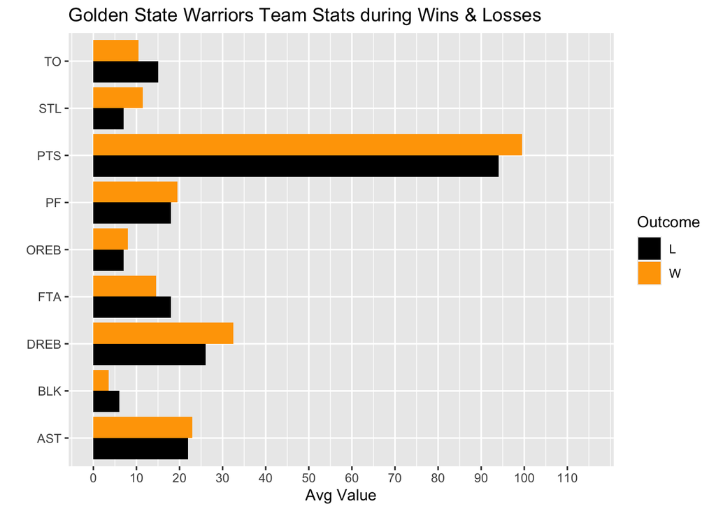

```r
dubs_team_stats
```

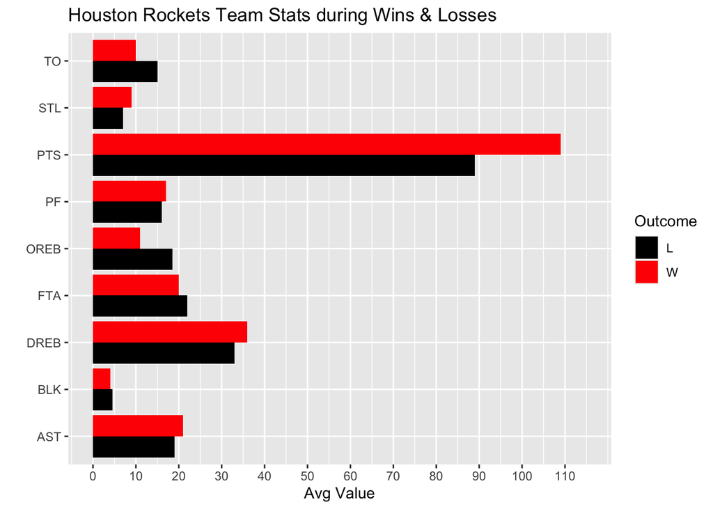

```r
rockets_team_stats
```

#### Team Analysis

**Warriors:**

- The Warriors seem to play a very consistent style of basketball as most of their team stats are pretty similar regardless of a win or loss.

**Rockets:**

- The Rockets similarly play a very consistent style of basketball but it seems that they are more reliant on scoring as in their one win they scored significantly more points than in their two losses.

## Player Statistics

This section will look to evaluate how well players on both the Warriors and the Rockets are doing by looking at their total plus-minus throughout the whole series.

```r
# Display player_stats that were previously loaded (only top 10 records shown)
player_stats %>%
  slice_head(n = 10) %>%
  kable(digits = 2)
```

| GAME_ID | TEAM_ID | TEAM_ABBREVIATION | TEAM_CITY | PLAYER_ID | PLAYER_NAME | NICKNAME | START_POSITION | COMMENT | MIN | FGM | FGA | FG_PCT | FG3M | FG3A | FG3_PCT | FTM | FTA | FT_PCT | OREB | DREB | REB | AST | STL | BLK | TO | PF | PTS | PLUS_MINUS |
| --- | --- | --- | --- | --- | --- | --- | --- | --- | --- | --- | --- | --- | --- | --- | --- | --- | --- | --- | --- | --- | --- | --- | --- | --- | --- | --- | --- | --- |
| 0042400151 | 1610612744 | GSW | Golden State | 1630541 | Moses Moody | Moses | F |  | 27.000000:54 | 2 | 5 | 0.4 | 1 | 4 | 0.25 | 2 | 2 | 1 | 1 | 1 | 2 | 1 | 0 | 0 | 1 | 3 | 7 | 6 |
| 0042400151 | 1610612744 | GSW | Golden State | 202710 | Jimmy Butler III | Jimmy | F |  | 42.000000:12 | 10 | 19 | 0.526 | 1 | 2 | 0.5 | 4 | 6 | 0.667 | 3 | 4 | 7 | 6 | 5 | 0 | 1 | 1 | 25 | 14 |
| 0042400151 | 1610612744 | GSW | Golden State | 203110 | Draymond Green | Draymond | C |  | 36.000000:29 | 2 | 5 | 0.4 | 0 | 2 | 0 | 0 | 0 | 0 | 1 | 5 | 6 | 3 | 3 | 1 | 2 | 4 | 4 | 4 |
| 0042400151 | 1610612744 | GSW | Golden State | 1641764 | Brandin Podziemski | Brandin | G |  | 35.000000:14 | 5 | 13 | 0.385 | 3 | 8 | 0.375 | 1 | 2 | 0.5 | 1 | 7 | 8 | 5 | 2 | 0 | 1 | 2 | 14 | 17 |
| 0042400151 | 1610612744 | GSW | Golden State | 201939 | Stephen Curry | Stephen | G |  | 39.000000:37 | 12 | 19 | 0.632 | 5 | 9 | 0.556 | 2 | 2 | 1 | 0 | 6 | 6 | 3 | 1 | 0 | 4 | 2 | 31 | 3 |
| 0042400151 | 1610612744 | GSW | Golden State | 1627780 | Gary Payton II | Gary |  |  | 15.000000:50 | 3 | 6 | 0.5 | 1 | 2 | 0.5 | 0 | 0 | 0 | 0 | 3 | 3 | 1 | 2 | 0 | 1 | 1 | 7 | -10 |
| 0042400151 | 1610612744 | GSW | Golden State | 1642366 | Quinten Post | Quinten |  |  | 12.000000:15 | 0 | 3 | 0 | 0 | 2 | 0 | 0 | 0 | 0 | 0 | 1 | 1 | 1 | 0 | 0 | 0 | 2 | 0 | 4 |
| 0042400151 | 1610612744 | GSW | Golden State | 1627741 | Buddy Hield | Buddy |  |  | 15.000000:19 | 1 | 4 | 0.25 | 0 | 2 | 0 | 0 | 0 | 0 | 0 | 1 | 1 | 0 | 1 | 0 | 0 | 1 | 2 | 7 |
| 0042400151 | 1610612744 | GSW | Golden State | 1626172 | Kevon Looney | Kevon |  |  | 8.000000:35 | 0 | 1 | 0 | 0 | 0 | 0 | 0 | 0 | 0 | 0 | 1 | 1 | 0 | 0 | 0 | 0 | 1 | 0 | 4 |
| 0042400151 | 1610612744 | GSW | Golden State | 1630611 | Gui Santos | Gui |  |  | 6.000000:35 | 1 | 1 | 1 | 1 | 1 | 1 | 2 | 2 | 1 | 0 | 1 | 1 | 0 | 0 | 0 | 1 | 1 | 5 | 1 |

```r
# Change columns to numeric
player_stats <- player_stats %>%
  mutate(across(FGM:PLUS_MINUS,
                ~ as.numeric(as.character(.))))

# Change minutes to be to numeric
player_stats <- player_stats %>%
  mutate(
    MIN = as.numeric(sub(":.*", "", MIN)) +
      as.numeric(sub(".*:",   "", MIN)) / 60)


# Warriors players plus minus who played at least 10 min
dubs_plus <- player_stats %>%
  filter(TEAM_ABBREVIATION == "GSW",
         MIN > 10) %>%
  group_by(TEAM_ABBREVIATION, PLAYER_NAME) %>%
  summarize(TOTAL_PLUS = sum(PLUS_MINUS, na.rm = TRUE)) %>%
  arrange(desc(TOTAL_PLUS))

# Graph it
dubs_players_plus_minus <- dubs_plus %>%
  ggplot(aes(x= reorder(PLAYER_NAME, TOTAL_PLUS),
             y= TOTAL_PLUS,
             fill = TOTAL_PLUS))+
  geom_col()+
  scale_fill_gradient(
    name    = "Plus-Minus",
    low     = "black",
    high    = "orange"
  )+
  labs(x = "",
       y = "Total Plus Minus",
       title = "Warrior's Players Total Plus-Minus vs Rockets (Games 1-3)")+
  scale_x_discrete(guide = guide_axis(angle = 45))



# Rockets players plus minus who played at least 10 min
rockets_plus <- player_stats %>%
  filter(TEAM_ABBREVIATION == "HOU",
         MIN > 10) %>%
  group_by(TEAM_ABBREVIATION,PLAYER_NAME) %>%
  summarize(TOTAL_PLUS = sum(PLUS_MINUS, na.rm = TRUE)) %>%
  arrange(desc(TOTAL_PLUS))


# Graph it
rockets_players_plus_minus <- rockets_plus %>%
  ggplot(aes(x= reorder(PLAYER_NAME, TOTAL_PLUS),
             y= TOTAL_PLUS,
             fill = TOTAL_PLUS))+
  geom_col()+
  scale_fill_gradient(
    name    = "Plus-Minus",
    low     = "black",
    high    = "red"
  )+
  labs(x = "",
       y = "Total Plus Minus",
       title = "Rocket's Players Total Plus-Minus vs Warriors (Games 1-3)")+
  scale_x_discrete(guide = guide_axis(angle = 45))
```

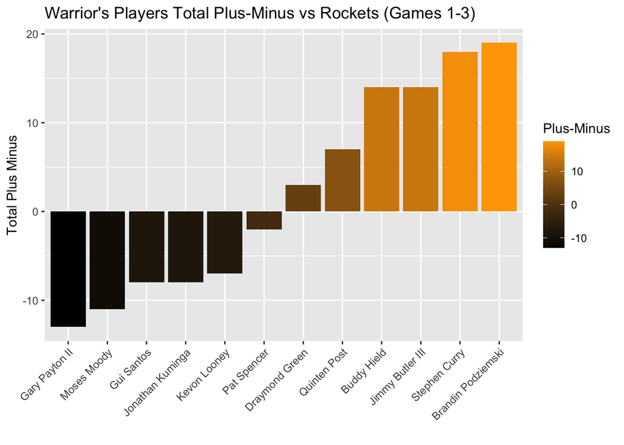

```r
dubs_players_plus_minus
```

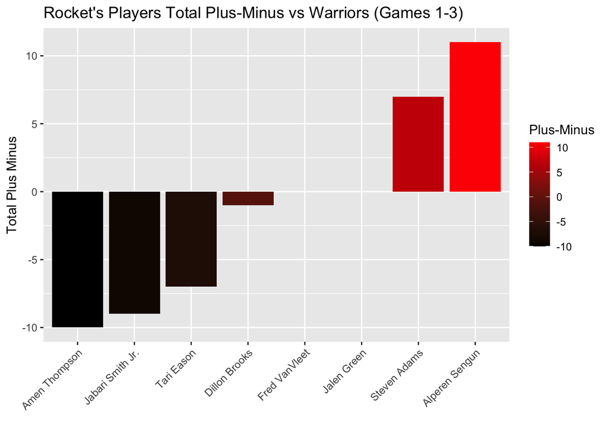

```r
rockets_players_plus_minus
```

#### Player Analysis

**Warriors:**

- No surprise that star players like Stephen Curry and Jimmy Butler are in the top 3 for the Warriors.
- However, Brandin Podziemski actually holds the title for the highest plus-minus of all Warriors players in this series which is even more impressive given that he had food poisoning during one of the games.
- Another shocking detail on the other side of the graph is that Moses Moody has the second lowest plus-minus on the team. The Warriors finished the season with a record of 27-7 when Moses Moody started games but he was benched in Game 3 after Jimmy Butler’s injury. When Butler played in Game 1, Moody had a plus-minus of +6 so it will be interesting to see if Steve Kerr will reinsert him back into the starting lineup when Butler returns.

**Rockets:**

- Alperen Sengun leading the way for the Rockets in plus-minus makes a lot of sense given how well he played during the regular season.
- One surprising player trailing right behind Sengun is longtime veteran center Steven Adams. A big takeaway from these top two players is that the Warriors struggle against size. Look for the Rockets to continue running their two center lineup with Adams and Sengun to try and exploit this weakness throughout the rest of the series.
- When looking at the opposite of the graph, we see that Amen Thompson and Jabari Smith Jr. have the lowest plus-minus for the Rockets. Both of these players are very young and this is their first playoff experience so some growing pains are expected. However, with three playoff games under their belt, don’t be surprised if their play begins to improve over the course of this series.